# Business Forecasting Final project (Taha Oussaifi)

## Overall summary

### Data Description

1) Importing the libraries2) Importing the dataset3) Plotting the graph4) ACF graph5) PACF graph

### Data tranformation

1)Testing stationarity through the ADF test2)Boc-Cox transformation3)Testing stationarity of transformed series through ADF test4)Taking the 1st difference5)Determining Rolling statistics6)Plotting the transformed differenced series 7)Testing the stationarity of the transformed differenced series through the ADF test

### Model selection & Fitting

1)Selective loop 2)Trying each of the models & selection of the best model3)Fitting the model4)Estimating the parameters of the model

### Testing the accuracy of the models

1)Optional step: Plotting both graphs (after re-scaling)2)Rescaling the forecasted values back to the original scale3)Rescaling the standard errors back to the original scale4)Rescaling the confidence interval back to the original scale5)Verification frame

### Forecasting

# Data Description

## Importing the libraries

```python
import numpy as np
import pandas as pd
import matplotlib.pylab as plt
%matplotlib inline
from matplotlib.pylab import rcParams
rcParams['figure.figsize'] = 10,6
```

```python
#to avoid warning messages
import warnings
warnings.filterwarnings("ignore")
%matplotlib inline
```

## Importing the dataset

#### Our dataset represents the number of miles flown by US airlines each month

#### This is the full dataset that we will be needing later to compare the last 20% of the values with the forecasted values

```python
#Importing the dataset
data=pd.read_csv('us-airlines-monthly-aircraft-miles-flown.csv')
data['Month']=pd.to_datetime(data['Month'], infer_datetime_format=True)
data=data.set_index(['Month'])
data
```

| Month | MilesMM |
| --- | --- |
| 1963-01-01 | 6827 |
| 1963-02-01 | 6178 |
| 1963-03-01 | 7084 |
| 1963-04-01 | 8162 |
| 1963-05-01 | 8462 |
| ... | ... |
| 1970-08-01 | 14057 |
| 1970-09-01 | 16234 |
| 1970-10-01 | 12389 |
| 1970-11-01 | 11595 |
| 1970-12-01 | 12772 |

96 rows × 1 columns

#### This is 80% of the dataset (training data), that we will be using to build our model

```python
dataset=pd.read_csv('us-airlines-monthly-aircraft-miles-flown.csv')
trained_dataset=dataset.iloc[0:78,]
trained_dataset['Month']=pd.to_datetime(trained_dataset['Month'], infer_datetime_format=True)
indexedDataset=trained_dataset.set_index(['Month'])
indexedDataset
```

| Month | MilesMM |
| --- | --- |
| 1963-01-01 | 6827 |
| 1963-02-01 | 6178 |
| 1963-03-01 | 7084 |
| 1963-04-01 | 8162 |
| 1963-05-01 | 8462 |
| ... | ... |
| 1969-02-01 | 8919 |
| 1969-03-01 | 11607 |
| 1969-04-01 | 8852 |
| 1969-05-01 | 12537 |
| 1969-06-01 | 14759 |

78 rows × 1 columns

## Plotting the graph

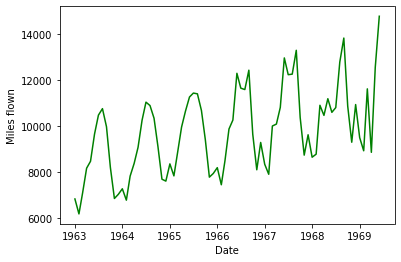

```python
#plotting the graph

plt.xlabel('Date')
plt.ylabel('Miles flown')
plt.plot(indexedDataset,color='green')
```

#### We can notice the presence of both a trend and seasonality in the time series plot. This indicates that our dataset is not stationary, which means that its mean and variance are time-structured (depend on time t)

## ACF graph

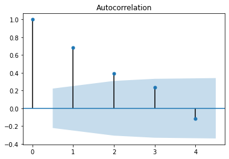

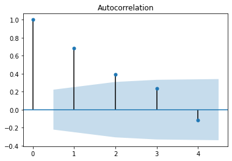

```python
#ACF graph
from statsmodels.graphics.tsaplots import plot_acf
plot_acf(indexedDataset['MilesMM'], lags=4)
```

#### We can see from the ACF graph, that there are 2 spikes above the confidence interval, which means that our data can be modelled by an MA(2) model

## PACF graph

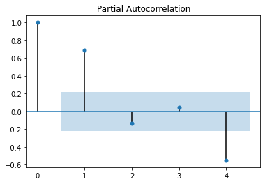

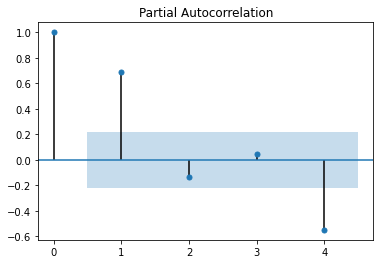

```python
from statsmodels.graphics.tsaplots import plot_pacf
plot_pacf(indexedDataset['MilesMM'], lags=4)
```

# Data Transformation

## Testing stationarity through the ADF test

```python
from statsmodels.tsa.stattools import adfuller
print('The results of the Dickey-Fuller test:')
print('H0: the data is not stationary')
print('H1: the data is stationary')
test=adfuller(indexedDataset['MilesMM'],autolag='AIC')
output=pd.Series(test[0:4], index=['test_statistic','p-value','#Lags_used','nber of obs used'])
for key,value in test[4].items():
    output[' Critical values (%s)'%key]= value
print(output)
```

```
The results of the Dickey-Fuller test:
H0: the data is not stationary
H1: the data is stationary
test_statistic            -0.823778
p-value                    0.812038
#Lags_used                11.000000
nber of obs used          66.000000
 Critical values (1%)     -3.533560
 Critical values (5%)     -2.906444
 Critical values (10%)    -2.590724
dtype: float64
```

#### The output of the ADF test indicates that the p-value is higher than the 5% critical value, which further indicates that our dataset is not stationary.

#### In order to make it stationary, we have to apply certain transformations, such as the Box-Cox transformation.

## Box-Cox transformation

```python
#Importing the necessary libraries
from scipy.stats import boxcox
from scipy.special import inv_boxcox
```

```python
y =indexedDataset.iloc[:,-1]
y,fitted_lambda= boxcox(y,lmbda=None)
inv_boxcox(y,fitted_lambda)
```

```
array([ 6827.,  6178.,  7084.,  8162.,  8462.,  9644., 10466., 10748.,
        9963.,  8194.,  6848.,  7027.,  7269.,  6775.,  7819.,  8371.,
        9069., 10248., 11030., 10882., 10333.,  9109.,  7685.,  7602.,
        8350.,  7829.,  8829.,  9948., 10638., 11253., 11424., 11391.,
       10665.,  9396.,  7775.,  7933.,  8186.,  7444.,  8484.,  9864.,
       10252., 12282., 11637., 11577., 12417.,  9637.,  8094.,  9280.,
        8334.,  7899.,  9994., 10078., 10801., 12950., 12222., 12246.,
       13281., 10366.,  8730.,  9614.,  8639.,  8772., 10894., 10455.,
       11179., 10588., 10794., 12770., 13812., 10857.,  9290., 10925.,
        9491.,  8919., 11607.,  8852., 12537., 14759.])
```

```python
fitted_lambda
```

```
0.22329940855665795
```

#### The value of lambda resulting from the Box-Cox transformation is 0.2232

```python
#Applying the transformation
indexedDataset_logscale=((indexedDataset**fitted_lambda)-1)/fitted_lambda
indexedDataset_logscale
```

| Month | MilesMM |
| --- | --- |
| 1963-01-01 | 27.680053 |
| 1963-02-01 | 26.970685 |
| 1963-03-01 | 27.946511 |
| 1963-04-01 | 28.988516 |
| 1963-05-01 | 29.259358 |
| ... | ... |
| 1969-02-01 | 29.657948 |
| 1969-03-01 | 31.726161 |
| 1969-04-01 | 29.600519 |
| 1969-05-01 | 32.354669 |
| 1969-06-01 | 33.721445 |

78 rows × 1 columns

#### This is our dataset, after applying the transformation

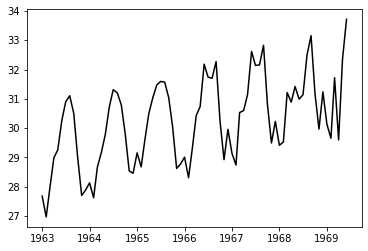

```python
#Plotting the transformed data
plt.plot(indexedDataset_logscale,color='black')
```

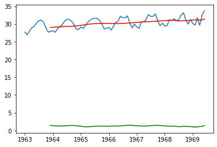

```python
movingAverage=indexedDataset_logscale.rolling(window=12).mean()
movingstd= indexedDataset_logscale.rolling(window=12).std()

plt.plot(indexedDataset_logscale)
plt.plot(movingAverage, color='red')
plt.plot(movingstd, color='green')
```

#### The above graph, is the plot of the transformed data in blue, alongside its moving average in red and the moving standard deviation in green

#### Even after applying the transformation, we can still notice the presence of trend and seasonality, which means that the transformed dataset is not stationary

## Testing stationarity of the transformed series through the ADF test

```python
from statsmodels.tsa.stattools import adfuller
print('The results of the Dickey-Fuller test:')
print('H0: the data is not stationary')
print('H1: the data is stationary')
test=adfuller(indexedDataset_logscale['MilesMM'],autolag='AIC')

output=pd.Series(test[0:4], index=['test_statistic','p-value','#Lags_used','nber of obs used'])
for key,value in test[4].items():
    output[' Critical values (%s)'%key]= value
print(output)
```

```
The results of the Dickey-Fuller test:
H0: the data is not stationary
H1: the data is stationary
test_statistic            -1.267153
p-value                    0.644063
#Lags_used                11.000000
nber of obs used          66.000000
 Critical values (1%)     -3.533560
 Critical values (5%)     -2.906444
 Critical values (10%)    -2.590724
dtype: float64
```

#### The output of the adf test indicates that the p-value of the transformed series is less that the p-value of the original series

#### However, it is still above the critical value of 95% confidence. Therefore, the transformed dataset is not stationary

## Taking the first difference of the dataset

```python
datasetLogDiffshifting=indexedDataset_logscale.diff(1)


datasetLogDiffshifting=datasetLogDiffshifting.dropna()
datasetLogDiffshifting.head(6)
```

| Month | MilesMM |
| --- | --- |
| 1963-02-01 | -0.709369 |
| 1963-03-01 | 0.975826 |
| 1963-04-01 | 1.042005 |
| 1963-05-01 | 0.270842 |
| 1963-06-01 | 0.999541 |
| 1963-07-01 | 0.640304 |

#### This is our dataset, after taking the first difference (The first value is missing)

## Determing rolling statisitics (rolling mean and std.dev)

```python
#Determining rolling statistics
rolmean=datasetLogDiffshifting.rolling(window=12).mean()
rolstd=datasetLogDiffshifting.rolling(window=12).std()
print(rolmean,rolstd)
```

```
             MilesMM
Month
1963-02-01       NaN
1963-03-01       NaN
1963-04-01       NaN
1963-05-01       NaN
1963-06-01       NaN
...              ...
1969-02-01  0.010537
1969-03-01  0.042409
1969-04-01 -0.107532
1969-05-01  0.077582
1969-06-01  0.227547

[77 rows x 1 columns]              MilesMM
Month
1963-02-01       NaN
1963-03-01       NaN
1963-04-01       NaN
1963-05-01       NaN
1963-06-01       NaN
...              ...
1969-02-01  1.134381
1969-03-01  1.189749
1969-04-01  1.343848
1969-05-01  1.573450
1969-06-01  1.605809

[77 rows x 1 columns]
```

## Plotting the transformed, differenced series

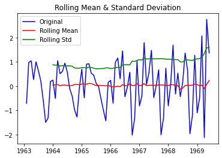

```python
orig= plt.plot(datasetLogDiffshifting, color='blue',label='Original')
mean=plt.plot(rolmean, color='red', label='Rolling Mean')
std= plt.plot(rolstd, color='green', label = 'Rolling Std')
plt.legend(loc='best')
plt.title('Rolling Mean & Standard Deviation')
plt.show(block=False)
```

#### We can see that after transforming and differencing the dataset, there is neither the trend nor the seasonality. This means that the transformed, differenced dataset is stationary

## Testing the stationarity of the transformed, differenced dataset through the ADF test

```python
from statsmodels.tsa.stattools import adfuller
print('The results of the Dickey-Fuller test:')
print('H0: the data is not stationary')
print('H1: the data is stationary')
test=adfuller(datasetLogDiffshifting['MilesMM'],autolag='AIC')
output=pd.Series(test[0:4], index=['test_statistic','p-value','#Lags_used','nber of obs used'])
for key,value in test[4].items():
    output[' Critical values (%s)'%key]= value
print(output)
```

```
The results of the Dickey-Fuller test:
H0: the data is not stationary
H1: the data is stationary
test_statistic            -4.254629
p-value                    0.000532
#Lags_used                11.000000
nber of obs used          65.000000
 Critical values (1%)     -3.535217
 Critical values (5%)     -2.907154
 Critical values (10%)    -2.591103
dtype: float64
```

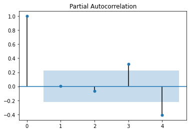

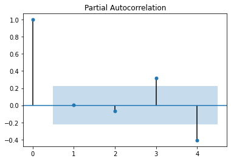

```python
from statsmodels.graphics.tsaplots import plot_pacf
plot_pacf(datasetLogDiffshifting['MilesMM'], lags=4)
```

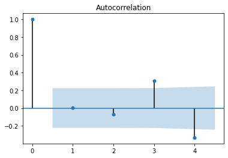

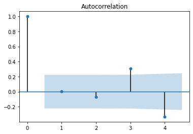

```python
from statsmodels.graphics.tsaplots import plot_acf
plot_acf(datasetLogDiffshifting['MilesMM'], lags=4)
```

#### The output of the ADF test indicates that the test-statistic is less than the critical value of 5%. Therefore, we conclude that the transformed, differenced dataset is stationary

# Model selection and fitting

## Selective loop

### We will run a loop that fits an ARIMA model for different values of p and q and selects the best model, that has the least AIC

### We will run this loop twice: the first one will fit a model with the least squares estimation method, and the second one with the maximum likelihood estimation method.

### Then, we will select the one with the lowest AIC

```python
from statsmodels.tsa.arima_model import ARIMA
```

```python
def evaluate_model_css(dataframe):
    i=0
    order_frame={'Order of AR':[],'Order of MA':[],'AIC':[]}
    order_frame=pd.DataFrame(order_frame)
    for p in range(0,4):

        for q in range(0,4):
            i=i+1
            model= ARIMA(dataframe,order=(p,1,q))
            results_ARIMA=model.fit(disp=1,method='css')
            order_frame.loc[i]=[p,q,results_ARIMA.aic]

    order_frame=order_frame.sort_values(by='AIC', ascending=True)
    print(order_frame)
```

```python
#This is the loop of the css method (least square estimation)
evaluate_model_css(indexedDataset_logscale)
```

```
    Order of AR  Order of MA         AIC
12          2.0          3.0  196.869971
16          3.0          3.0  199.795701
15          3.0          2.0  205.237687
14          3.0          1.0  205.578488
10          2.0          1.0  209.122620
11          2.0          2.0  209.138706
13          3.0          0.0  213.171504
8           1.0          3.0  214.401110
4           0.0          3.0  215.323722
3           0.0          2.0  219.135307
7           1.0          2.0  221.063914
6           1.0          1.0  222.292597
9           2.0          0.0  223.239933
5           1.0          0.0  224.292665
1           0.0          0.0  224.771645
2           0.0          1.0  226.771529
```

### The table below gives the sorted models from best to worst according to thier AIC. We can see that ARIMA(2,1,3) is better than both the AR(1) and MA(2) found previsouly using the ACF and PACF plots

```python
def evaluate_model_mle(dataframe):
    i=0
    order_frame={'Order of AR':[],'Order of MA':[],'AIC':[]}
    order_frame=pd.DataFrame(order_frame)
    for p in range(0,4):

        for q in range(0,4):
            i=i+1
            model= ARIMA(dataframe,order=(p,1,q))
            results_ARIMA=model.fit(disp=1,method='mle')
            order_frame.loc[i]=[p,q,results_ARIMA.aic]

    order_frame=order_frame.sort_values(by='AIC', ascending=True)
    print(order_frame)
```

```python
#This is the loop of the mle method
evaluate_model_mle(indexedDataset_logscale)
```

```
    Order of AR  Order of MA         AIC
12          2.0          3.0  201.693916
16          3.0          3.0  204.660279
14          3.0          1.0  212.776515
11          2.0          2.0  214.157697
7           1.0          2.0  215.762172
3           0.0          2.0  215.837933
4           0.0          3.0  215.878104
8           1.0          3.0  217.526655
15          3.0          2.0  219.797265
10          2.0          1.0  220.805967
13          3.0          0.0  220.959038
1           0.0          0.0  224.771645
2           0.0          1.0  226.771529
5           1.0          0.0  226.771545
9           2.0          0.0  228.366286
6           1.0          1.0  228.770666
```

### The table below gives the sorted models from best to worst according to thier AIC. We can see that ARIMA(2,1,3) is better than both the AR(1) and MA(2) found previsouly using the ACF and PACF plots

### We will check the results of the table by fitting each of the aformentioned models, and selecting the one with the lowest AIC

## Trying each of the models & selection of the best model

### ARI(1,1,0)

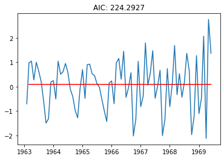

```python
model= ARIMA(indexedDataset_logscale,order=(1,1,0))
results_ARIMA=model.fit(disp=1,method='css')
plt.plot(datasetLogDiffshifting)
plt.plot(results_ARIMA.fittedvalues,color='red')
plt.title('AIC: %.4f'% results_ARIMA.aic)
```

### IMA(0,1,2)

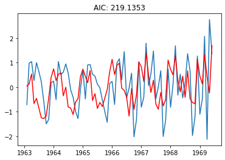

```python
model= ARIMA(indexedDataset_logscale,order=(0,1,2))
results_ARIMA=model.fit(disp=1,method='css')
plt.plot(datasetLogDiffshifting)
plt.plot(results_ARIMA.fittedvalues,color='red')
plt.title('AIC: %.4f'% results_ARIMA.aic)
```

### ARIMA(2,1,3)

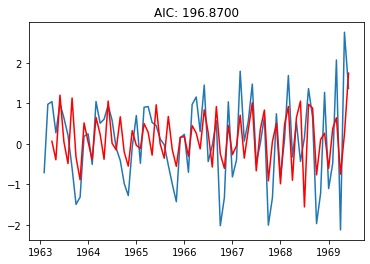

```python
model= ARIMA(indexedDataset_logscale,order=(2,1,3))
results_ARIMA=model.fit(disp=1,method='css')
plt.plot(datasetLogDiffshifting)
plt.plot(results_ARIMA.fittedvalues,color='red')
plt.title('AIC: %.4f'% results_ARIMA.aic)
```

### ARI(1,1,0)

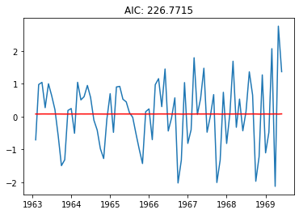

```python
model= ARIMA(indexedDataset_logscale,order=(1,1,0))
results_ARIMA=model.fit(disp=1,method='mle')
plt.plot(datasetLogDiffshifting)
plt.plot(results_ARIMA.fittedvalues,color='red')
plt.title('AIC: %.4f'% results_ARIMA.aic)
```

### IMA(0,1,2)

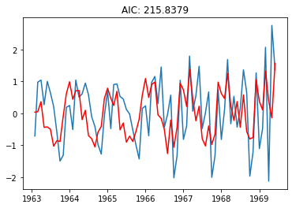

```python
model= ARIMA(indexedDataset_logscale,order=(0,1,2))
results_ARIMA=model.fit(disp=1,method='mle')
plt.plot(datasetLogDiffshifting)
plt.plot(results_ARIMA.fittedvalues,color='red')
plt.title('AIC: %.4f'% results_ARIMA.aic)
```

### ARIMA(2,1,3)

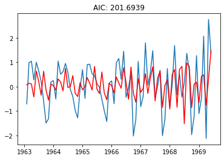

```python
model= ARIMA(indexedDataset_logscale,order=(2,1,3))
results_ARIMA=model.fit(disp=1,method='mle')
plt.plot(datasetLogDiffshifting)
plt.plot(results_ARIMA.fittedvalues,color='red')
plt.title('AIC: %.4f'% results_ARIMA.aic)
```

#### We can conclude that we should select the ARIMA(2,1,3) with the least square estimation method for our prediction as it has the lowest AIC

## Fitting an ARIMA(2,1,3) model

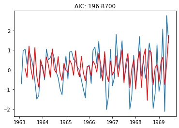

```python
model= ARIMA(indexedDataset_logscale,order=(2,1,3))
results_ARIMA=model.fit(disp=1,method='css')
plt.plot(datasetLogDiffshifting)
plt.plot(results_ARIMA.fittedvalues,color='red')
plt.title('AIC: %.4f'% results_ARIMA.aic)
```

## Estimating the parmaters of the models

```python
results_ARIMA.params
```

```
const              0.127775
ar.L1.D.MilesMM   -1.064828
ar.L2.D.MilesMM   -1.000000
ma.L1.D.MilesMM    1.325885
ma.L2.D.MilesMM    1.283346
ma.L3.D.MilesMM    0.413331
dtype: float64
```

# Testing the accuracy of the model

## Plotting both graphs (optional step)

In this section, we will try to plot the model fitted values with the actual dataset values. This would not be of much help to forecast. It will, nonetheless, help us verify that the fitted model gives values that are closer to the original dataset values. To do so, we have to rescale the fitted values back to the original scale of the dataset values, by offsetting both the effect of differencing and Box-Cox transformation

### Extracting the fitted values

```python
predictions_ARIMA_diff=pd.Series(results_ARIMA.fittedvalues, copy=True)
print(predictions_ARIMA_diff)
```

```
Month
1963-04-01    0.061889
1963-05-01   -0.394253
1963-06-01    1.200871
1963-07-01    0.048146
1963-08-01   -0.488085
                ...
1969-02-01    0.379899
1969-03-01    0.643059
1969-04-01   -0.750445
1969-05-01    0.238215
1969-06-01    1.744602
Length: 75, dtype: float64
```

### Cumulative sum

```python
predictions_ARIMA_diff_cumsum=predictions_ARIMA_diff.cumsum()
print(predictions_ARIMA_diff_cumsum)
```

```
Month
1963-04-01    0.061889
1963-05-01   -0.332364
1963-06-01    0.868506
1963-07-01    0.916652
1963-08-01    0.428568
                ...
1969-02-01    7.226690
1969-03-01    7.869748
1969-04-01    7.119303
1969-05-01    7.357518
1969-06-01    9.102120
Length: 75, dtype: float64
```

### Adding the cumulative sum to a base value

```python
predictions_ARIMA_log=pd.Series(indexedDataset_logscale['MilesMM'].ix[0],index = indexedDataset_logscale.index)
predictions_ARIMA_log=predictions_ARIMA_log.add(predictions_ARIMA_diff_cumsum, fill_value=0)
predictions_ARIMA_log.head()
```

```
Month
1963-01-01    27.680053
1963-02-01    27.680053
1963-03-01    27.680053
1963-04-01    27.741942
1963-05-01    27.347689
dtype: float64
```

## Offsetting the effect of the transformation

```python
predictions_ARIMA=(fitted_lambda*predictions_ARIMA_log+1)**(1/fitted_lambda)
#This is the reverse function of the Box-Cox transformation
```

## Plotting both time series together

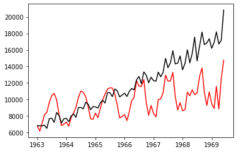

```python
plt.plot(indexedDataset, color='red')
plt.plot(predictions_ARIMA, color='black')
```

## Plotting the forecasted values with 95% confidence interval

```python
# This is the remaining 20% of the actual data that we will compare with the forecasted values
remaining_data=data.iloc[78:,:]
remaining_data.info()
```

```
<class 'pandas.core.frame.DataFrame'>
DatetimeIndex: 18 entries, 1969-07-01 to 1970-12-01
Data columns (total 1 columns):
MilesMM    18 non-null int64
dtypes: int64(1)
memory usage: 288.0 bytes
```

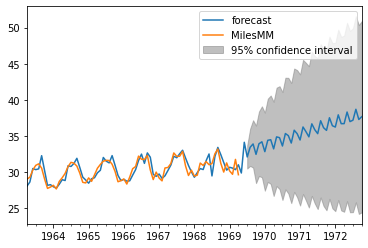

```python
results_ARIMA.plot_predict(3,117)
x=results_ARIMA.forecast(steps=18) # 18 is the number of values we set aside earlier in our original dataset
```

```python
remaining_data=remaining_data.to_numpy()
remaining_data
```

```
array([[13667],
       [13731],
       [15110],
       [12185],
       [10645],
       [12161],
       [10840],
       [10436],
       [13589],
       [13402],
       [13103],
       [14933],
       [14147],
       [14057],
       [16234],
       [12389],
       [11595],
       [12772]], dtype=int64)
```

```python
x
```

```
(array([32.06297241, 33.40882363, 33.86963642, 32.42470629, 33.89410243,
        34.1659861 , 32.79868802, 34.37434853, 34.45544691, 33.18503792,
        34.84831352, 34.73922783, 33.58371702, 35.31482992, 35.01861102,
        33.99452754, 35.77282618, 35.29493527]),
 array([0.8188901 , 1.31794674, 1.67704476, 2.037476  , 2.2807241 ,
        2.50899298, 2.76238393, 2.94390544, 3.12709279, 3.33300403,
        3.48306442, 3.64189076, 3.81912889, 3.94934172, 4.09254258,
        4.24985373, 4.36616371, 4.49835365]),
 array([[30.45797731, 33.66796751],
        [30.82569548, 35.99195178],
        [30.5826891 , 37.15658375],
        [28.43132672, 36.41808586],
        [29.42396534, 38.36423953],
        [29.24845022, 39.08352199],
        [27.38451501, 38.21286103],
        [28.60439989, 40.14429716],
        [28.32645767, 40.58443614],
        [26.65247006, 39.71760578],
        [28.0216327 , 41.67499433],
        [27.6012531 , 41.87720256],
        [26.09836194, 41.0690721 ],
        [27.57426238, 43.05539745],
        [26.99737495, 43.03984709],
        [25.6649673 , 42.32408779],
        [27.21530256, 44.3303498 ],
        [26.47832413, 44.11154641]]))
```

#### x is the output of the function .forecast(): It gives 3 arrays, the first one contains the forecasted values, the second one contains the standard errors, and the third one contains the 95% confidence interval of each actual value

## Rescaling the forecasted values to the original scale

```python
pow(fitted_lambda*x[0]+1,1/fitted_lambda)
```

```
array([12098.45138271, 14225.73369701, 15017.14387319, 12644.11060251,
       15060.09779955, 15543.88499464, 13228.14757019, 15922.74404757,
       16072.12609669, 13853.2858396 , 16811.25945513, 16603.43404754,
       14522.18601509, 17722.95158762, 17139.73616667, 15237.41060989,
       18654.89812936, 17683.30561191])
```

## Rescaling the standard errors to the original scale

```python
pow(fitted_lambda*x[1]+1,1/fitted_lambda)
```

```
array([ 2.12135333,  3.17482895,  4.15555104,  5.36172097,  6.31813751,
        7.33142386,  8.5994452 ,  9.60787328, 10.71634057, 12.07822813,
       13.15260268, 14.36910738, 15.82793114, 16.97105122, 18.30115389,
       19.85417952, 21.06678172, 22.51395005])
```

## Rescaling the confidence interval to the original scale

```python
interval=pow(fitted_lambda*x[2]+1,1/fitted_lambda)
interval
```

```
array([[ 9893.99167615, 14666.69565269],
       [10368.96435833, 19114.02353794],
       [10053.14316985, 21703.5702162 ],
       [ 7570.82829237, 20031.98455594],
       [ 8648.46803712, 24668.45501568],
       [ 8449.75498279, 26578.08740811],
       [ 6550.48519219, 24280.50633545],
       [ 7750.77088541, 29601.69287168],
       [ 7463.3865306 , 30931.87389025],
       [ 5902.9394689 , 28354.990489  ],
       [ 7157.79516263, 34428.17205257],
       [ 6752.40238564, 35108.83339612],
       [ 5446.76418843, 32449.74863766],
       [ 6726.99725113, 39285.39755256],
       [ 6201.51509747, 39227.87536154],
       [ 5109.45157524, 36650.18556042],
       [ 6396.12968983, 44229.29417973],
       [ 5756.49325083, 43348.25911352]])
```

```python
checking_frame={'Actual value':[],"interval's lower limit":[],"interval's upper limit":[],'Verification':[]}
checking_frame=pd.DataFrame(checking_frame)
for i in range(0,18):
    Bool=''
    if remaining_data[i]>=interval[i][0] and remaining_data[i]<=interval[i][1]:
        Bool='Belongs to the interval'
        checking_frame.loc[i]=[remaining_data[i],interval[i][0],interval[i][1],Bool]
    else:
        Bool="Doesn't belong to the interval"
        checking_frame.loc[i]=[remaining_data[i],interval[i][0],interval[i][1],Bool]
```

The above code block tests whether the actual values fall within the 95% confidence interval or not

## Verification frame

```python
checking_frame
```

|  | Actual value | interval's lower limit | interval's upper limit | Verification |
| --- | --- | --- | --- | --- |
| 0 | [13667] | 9893.991676 | 14666.695653 | Belongs to the interval |
| 1 | [13731] | 10368.964358 | 19114.023538 | Belongs to the interval |
| 2 | [15110] | 10053.143170 | 21703.570216 | Belongs to the interval |
| 3 | [12185] | 7570.828292 | 20031.984556 | Belongs to the interval |
| 4 | [10645] | 8648.468037 | 24668.455016 | Belongs to the interval |
| 5 | [12161] | 8449.754983 | 26578.087408 | Belongs to the interval |
| 6 | [10840] | 6550.485192 | 24280.506335 | Belongs to the interval |
| 7 | [10436] | 7750.770885 | 29601.692872 | Belongs to the interval |
| 8 | [13589] | 7463.386531 | 30931.873890 | Belongs to the interval |
| 9 | [13402] | 5902.939469 | 28354.990489 | Belongs to the interval |
| 10 | [13103] | 7157.795163 | 34428.172053 | Belongs to the interval |
| 11 | [14933] | 6752.402386 | 35108.833396 | Belongs to the interval |
| 12 | [14147] | 5446.764188 | 32449.748638 | Belongs to the interval |
| 13 | [14057] | 6726.997251 | 39285.397553 | Belongs to the interval |
| 14 | [16234] | 6201.515097 | 39227.875362 | Belongs to the interval |
| 15 | [12389] | 5109.451575 | 36650.185560 | Belongs to the interval |
| 16 | [11595] | 6396.129690 | 44229.294180 | Belongs to the interval |
| 17 | [12772] | 5756.493251 | 43348.259114 | Belongs to the interval |

## The frame shows that all values of the testing dataset fall within the 95% confidence interval. Therefore, we conclude that the accuracy of the model is significant to consider our model reliable for forecasting future values

# Forecasting

```python
future_20=results_ARIMA.forecast(steps=38) #38=18 (the values compared with the testing set)+20 (the next 20 values to be forecasted)
```

```python
future_20[0]
```

```
array([32.06297241, 33.40882363, 33.86963642, 32.42470629, 33.89410243,
       34.1659861 , 32.79868802, 34.37434853, 34.45544691, 33.18503792,
       34.84831352, 34.73922783, 33.58371702, 35.31482992, 35.01861102,
       33.99452754, 35.77282618, 35.29493527, 34.41711544, 36.2213405 ,
       35.56957877, 34.85097499, 36.65953321, 35.84394136, 35.29545527,
       37.08669758, 36.11942651, 35.74976856, 37.50226892, 36.39742322,
       36.2130005 , 37.90583189, 36.67928813, 36.68412184, 38.29712579,
       36.96632808, 37.16200173, 38.67604798])
```

```python
#Applying the reverse of the Box-Cox transformation
pow(fitted_lambda*future_20[0]+1,1/fitted_lambda)
```

```
array([12098.45138271, 14225.73369701, 15017.14387319, 12644.11060251,
       15060.09779955, 15543.88499464, 13228.14757019, 15922.74404757,
       16072.12609669, 13853.2858396 , 16811.25945513, 16603.43404754,
       14522.18601509, 17722.95158762, 17139.73616667, 15237.41060989,
       18654.89812936, 17683.30561191, 16001.38505976, 19604.00631997,
       18236.74276569, 16816.35510432, 20567.08097212, 18802.95346018,
       17684.34098648, 21540.8993809 , 19385.12482102, 18607.08918258,
       22522.29109802, 19986.6994021 , 19586.02265079, 23508.22029433,
       20611.34813909, 20622.19086044, 24495.86828937, 21262.94248037,
       21716.22112531, 25482.71379503])
```

```python
#Next 20 values
future_20[0][18:38]
```

```
array([34.41711544, 36.2213405 , 35.56957877, 34.85097499, 36.65953321,
       35.84394136, 35.29545527, 37.08669758, 36.11942651, 35.74976856,
       37.50226892, 36.39742322, 36.2130005 , 37.90583189, 36.67928813,
       36.68412184, 38.29712579, 36.96632808, 37.16200173, 38.67604798])
```

The model predicts, that for the next 20 months (beyond 12/1970) will be as follows:

```python
# Next 20 values rescaled
pow(fitted_lambda*future_20[0][18:38]+1,1/fitted_lambda)
```

```
array([16001.38505976, 19604.00631997, 18236.74276569, 16816.35510432,
       20567.08097212, 18802.95346018, 17684.34098648, 21540.8993809 ,
       19385.12482102, 18607.08918258, 22522.29109802, 19986.6994021 ,
       19586.02265079, 23508.22029433, 20611.34813909, 20622.19086044,
       24495.86828937, 21262.94248037, 21716.22112531, 25482.71379503])
```